# 01 — Trait-value computation: environment-adjusted BLUEs (fixed-effects model)

**The problem this solves.** Each hybrid is grown in a *wildly* unbalanced set of environments (median 10 environments/genotype, range 1–127). A simple average of a genotype's plot records therefore confounds its genetics with *which* environments it happened to be grown in — a genotype tested mostly in high-yielding sites looks good for reasons that aren't genetic. Feeding such averages to GWAS injects that confounding into the association signal.

**What this notebook does.** For each trait × stress category, fit a model that estimates a genotype effect **adjusted for environment, replicate and block**, and take the genotype **BLUE** (Best Linear Unbiased Estimator) as the trait value. The stress categorization is kept byte-identical to the upstream definition; only the per-genotype trait value changes. Output: 16 `blue_pheno/{trait}_{stress}.csv` tables (`Taxa,<trait>`), the phenotype input to BLINK.

**Model (fixed-effects, base R `lm`), per trait × stress category**

$$\text{trait}_{ij} = \mu + g_i + d_j + \varepsilon$$

- $g_i$ **genotype — fixed** → its estimate is the BLUE we want (no shrinkage, correct for stage-2 GWAS)
- $d_j$ **environment:rep:block — fixed** → one nested factor that absorbs the environment, replicate and block effects, removing the environment-imbalance confounding
- $\varepsilon$ residual

Solved with base R `lm` (`compute_blue.R`). This is a fixed-effects BLUE: standard, fully deconfounds environment, fast at this scale, and the genotype **values** — which is all the GWAS consumes — are what we keep. (A mixed model with rep/block as random effects barely changes those values and is impractically slow with ~4,300 genotypes as fixed effects, so it is not used here.)

```python
import os, subprocess
from pathlib import Path
import numpy as np, pandas as pd, matplotlib.pyplot as plt
plt.rcParams.update({"figure.dpi": 110, "font.size": 10, "axes.grid": True, "grid.alpha": 0.25})

PROJECT   = Path("/path/to/PLANT_PROJECT")
PHENO_RAW = PROJECT/"project_input_data"/"PHENO.csv"                        # raw plot-level
STRESS    = PROJECT/"project_input_data"/"Heat_Drought_Stress_Indices.csv" # year_loc -> CATEGORY
GENO      = PROJECT/"project_input_data"/"GENO.csv"                         # 98,026 numeric SNPs

EXP       = PROJECT/"local_experiments"
PHENO_OUT = EXP/"blue_pheno";   PHENO_OUT.mkdir(parents=True, exist_ok=True)
RESULTS   = EXP/"results_blue"                                              # BLINK output dir
FIGDIR    = EXP/"figures";       FIGDIR.mkdir(exist_ok=True)
RSCRIPT   = "Rscript"
RBLUE     = EXP/"compute_blue.R"

TRAITS = ["yield","anthesis","silking","ASI"]
STRESS_CATS = ["NO_STRESS","HEAT_STRESSED","DROUGHT_STRESSED","HEAT_DROUGHT_STRESSED"]
print("outputs ->", EXP)
```

```
outputs -> /path/to/PLANT_PROJECT/local_experiments
```

## 1. Raw data & stress categorization

`PHENO.csv` is the raw plot-level table (78,686 records: `year_loc`, `genotype`, `rep`, `block`, the four traits, …). Stress category per environment is taken straight from the `CATEGORY` column of `Heat_Drought_Stress_Indices.csv` and joined on `year_loc`, so the grouping is unchanged.

```python
ph  = pd.read_csv(PHENO_RAW)
idx = pd.read_csv(STRESS)[["year_location","CATEGORY"]]
ph  = ph.merge(idx, left_on="year_loc", right_on="year_location", how="left")
assert ph["CATEGORY"].notna().all(), "unmapped environments!"
print("plot records:", len(ph), "| genotypes:", ph.genotype.nunique(), "| environments:", ph.year_loc.nunique())
display(ph.groupby("CATEGORY")
          .agg(n_plots=("genotype","size"), n_envs=("year_loc","nunique"), n_geno=("genotype","nunique"))
          .reindex(STRESS_CATS))
epg = ph.groupby("genotype").year_loc.nunique()
print(f"\nenvironments per genotype: median={epg.median():.0f} mean={epg.mean():.1f} max={epg.max()} "
      f"| single-environment genotypes: {(epg==1).sum()}  (this imbalance is what the BLUE corrects)")
```

```
plot records: 78686 | genotypes: 4372 | environments: 136
```

| CATEGORY | n_plots | n_envs | n_geno |
| --- | --- | --- | --- |
| NO_STRESS | 48277 | 80 | 4298 |
| HEAT_STRESSED | 18495 | 34 | 3559 |
| DROUGHT_STRESSED | 1999 | 3 | 621 |
| HEAT_DROUGHT_STRESSED | 9915 | 19 | 2678 |

```
environments per genotype: median=10 mean=11.9 max=127 | single-environment genotypes: 130  (this imbalance is what the BLUE corrects)
```

## 2. BLUE computation

Run `compute_blue.R` (skips if the 16 outputs already exist; the command is shown for provenance). It fits the model above per trait × stress category and writes `blue_pheno/{trait}_{stress}.csv`. `corr_BLUE_vs_naive` is how far the adjusted values move from a naive average — the lower, the more the environment imbalance was distorting that condition; `n_aliased` counts genotypes not separable from the block design (dropped).

```python
summary_path = PHENO_OUT/"_blue_summary.tsv"
n_have = len(list(PHENO_OUT.glob("*_*.csv")))
print("R cmd:", RSCRIPT, RBLUE)
if summary_path.exists() and n_have >= 16:
    print(f"  -> {n_have} BLUE files present, skipping recompute")
else:
    env = os.environ.copy(); env.update(OPENBLAS_NUM_THREADS="1", OMP_NUM_THREADS="1", BLUE_CORES="8")
    r = subprocess.run([RSCRIPT, str(RBLUE)], capture_output=True, text=True, env=env)
    print(r.stdout[-2000:]);  print(("FAILED:\n"+r.stderr[-800:]) if r.returncode else "  done.")
S = pd.read_csv(summary_path, sep="\t")
display(S.sort_values(["trait","stress"]).reset_index(drop=True))
print(f"BLUE↔naive correlation: median {S.corr_BLUE_vs_naive.median():.2f}, "
      f"range {S.corr_BLUE_vs_naive.min():.2f}–{S.corr_BLUE_vs_naive.max():.2f}")
```

```
R cmd: Rscript /path/to/PLANT_PROJECT/local_experiments/compute_blue.R
  -> 16 BLUE files present, skipping recompute
```

|  | trait | stress | n_geno | n_aliased | corr_BLUE_vs_naive |
| --- | --- | --- | --- | --- | --- |
| 0 | ASI | DROUGHT_STRESSED | 621 | 0 | 0.968 |
| 1 | ASI | HEAT_DROUGHT_STRESSED | 2678 | 0 | 0.728 |
| 2 | ASI | HEAT_STRESSED | 3559 | 0 | 0.767 |
| 3 | ASI | NO_STRESS | 4298 | 0 | 0.838 |
| 4 | anthesis | DROUGHT_STRESSED | 621 | 0 | 0.976 |
| 5 | anthesis | HEAT_DROUGHT_STRESSED | 2678 | 0 | 0.181 |
| 6 | anthesis | HEAT_STRESSED | 3559 | 0 | 0.393 |
| 7 | anthesis | NO_STRESS | 4298 | 0 | 0.538 |
| 8 | silking | DROUGHT_STRESSED | 621 | 0 | 0.986 |
| 9 | silking | HEAT_DROUGHT_STRESSED | 2678 | 0 | 0.179 |
| 10 | silking | HEAT_STRESSED | 3559 | 0 | 0.371 |
| 11 | silking | NO_STRESS | 4298 | 0 | 0.564 |
| 12 | yield | DROUGHT_STRESSED | 621 | 0 | 0.563 |
| 13 | yield | HEAT_DROUGHT_STRESSED | 2678 | 0 | 0.706 |
| 14 | yield | HEAT_STRESSED | 3559 | 0 | 0.640 |
| 15 | yield | NO_STRESS | 4298 | 0 | 0.777 |

```
BLUE↔naive correlation: median 0.67, range 0.18–0.99
```

## 3. QC — how much did the environment adjustment move the trait?

If naive averaging were unbiased, BLUE ≈ naive mean (points on the y=x line). Departure from the line is the confounding the BLUE removes; lower correlation = more environment-imbalance distortion.

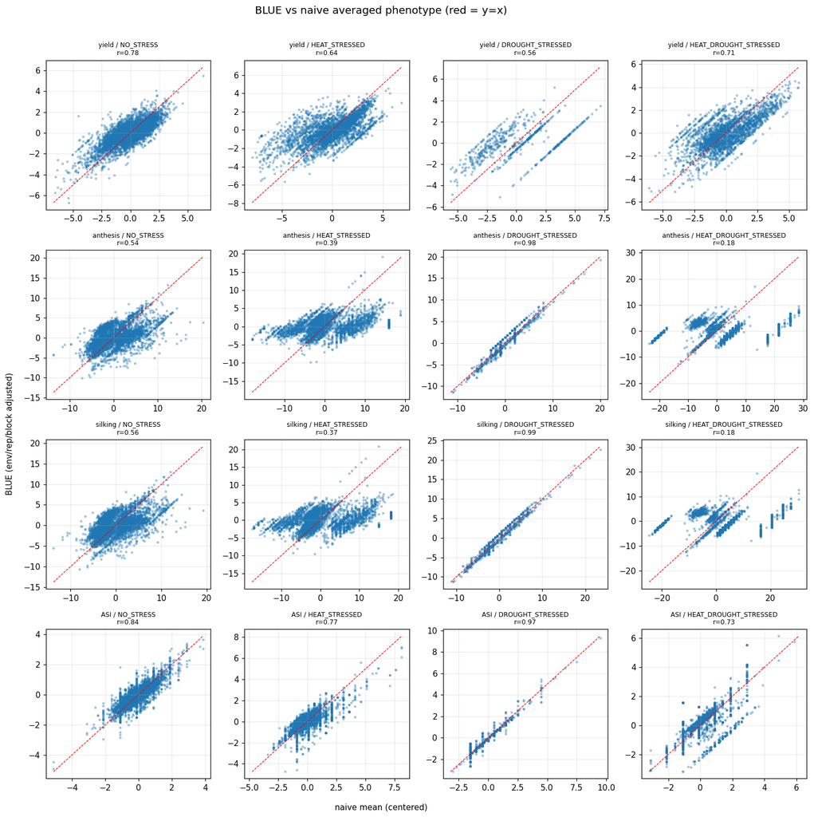

```python
fig, axes = plt.subplots(4, 4, figsize=(15, 15)); axes = axes.ravel(); k = 0
for trait in TRAITS:
    for cat in STRESS_CATS:
        ax = axes[k]; k += 1
        blue = pd.read_csv(PHENO_OUT/f"{trait}_{cat}.csv")          # Taxa,<trait>
        naive = (ph[ph.CATEGORY==cat].groupby("genotype")[trait].mean())
        naive = (naive - naive.mean()).rename("naive")
        m = blue.merge(naive, left_on="Taxa", right_index=True)
        x, y = m["naive"], m[trait]
        ax.scatter(x, y, s=5, alpha=0.3, rasterized=True)
        lo, hi = np.nanmin([x.min(), y.min()]), np.nanmax([x.max(), y.max()])
        ax.plot([lo, hi], [lo, hi], "r--", lw=0.8)
        ax.set_title(f"{trait} / {cat}\nr={np.corrcoef(y, x)[0,1]:.2f}", fontsize=8)
fig.text(0.5, 0.07, "naive mean (centered)", ha="center")
fig.text(0.07, 0.5, "BLUE (env/rep/block adjusted)", va="center", rotation="vertical")
fig.suptitle("BLUE vs naive averaged phenotype (red = y=x)", y=0.99, fontsize=13)
fig.tight_layout(rect=[0.08, 0.08, 1, 0.98])
fig.savefig(FIGDIR/"blue_vs_naive.png", dpi=600, bbox_inches="tight"); fig.savefig(FIGDIR/"blue_vs_naive.pdf"); plt.show()
```

## 4. BLINK inputs

Genotypes are unchanged, so the GAPIT map is regenerated from `GENO.csv` (idempotent) and the BLUEs feed the existing Nextflow pipeline. The job manifest `gwas_jobs.csv` already points at `blue_pheno/{trait}_{stress}.csv`, so re-running BLINK is just:

```
cd local_experiments/nextflow && nextflow run main.nf --model BLINK
```

(BLINK settings unchanged — `PCA.total=5`, GAPIT defaults — so the only thing that changed between runs is the trait value.)

```python
def create_gapit_map(geno_path, output_path):
    # GAPIT map (CHROM,POS,SNP ID) from GENO.csv column names 'S{chrom}_{pos}'
    cols = pd.read_csv(geno_path, nrows=0).columns[1:]
    df = pd.DataFrame({"CHROM": [int(c.split("_")[0][1:]) for c in cols],
                       "POS":   [int(c.split("_")[1])     for c in cols], "SNP ID": cols})
    df.to_csv(output_path, index=False); print(f"map written: {output_path} ({len(df)} SNPs)"); return output_path

create_gapit_map(GENO, EXP/"snpnames.csv")
jobs = EXP/"gwas_jobs.csv"
if jobs.exists():
    jm = pd.read_csv(jobs, header=None, names=["geno","map","pheno","output_dir","model"])
    print(f"\nmanifest {jobs.name}: {len(jm)} jobs ({(jm.model=='BLINK').sum()} BLINK)")
    print("phenotypes point at:", jm.pheno.iloc[0].rsplit('/',2)[0] + "/...")
```

```
map written: /path/to/PLANT_PROJECT/local_experiments/snpnames.csv (98026 SNPs)

manifest gwas_jobs.csv: 32 jobs (16 BLINK)
phenotypes point at: /path/to/PLANT_PROJECT/local_experiments/...
```

## 5. Next

1. **Remove the stale BLINK results** computed from the previous trait values, then **re-run BLINK** on these BLUEs: `nextflow run main.nf --model BLINK`.
2. **Re-run the LD-decay / candidate-locus analysis** (`03_ld_decay`) on the new BLINK output.